# FakeFace3 - Data Cleaning

## Data Preparation

```r
library(tidyverse)
library(easystats)
library(patchwork)
library(ggside)
```

```r
df <-read.csv("https://raw.githubusercontent.com/RealityBending/FakeFace3/refs/heads/main/data/rawdata_participants.csv") |>
  mutate(Gender = case_when(
           Gender == "Female" ~ "Woman",
           Gender == "Male" ~ "Man",
           Gender == "Genderfluid" ~ "Non-binary",
           TRUE ~ Gender),
         SexualOrientation = case_when(
           SexualOrientation == "asexual" ~ "Asexual",
           SexualOrientation == "queer" ~ "Queer",
            is.na(SexualOrientation) ~ "Prefer not to say",
           TRUE ~ SexualOrientation),
         Ethnicity = case_when(
           Ethnicity == "portuguese" ~ "White",
           Ethnicity == "latino (brazilian) and white (portuguese)" ~ "Mixed",
           Ethnicity == "middle eastern/ european" ~ "Mixed",
         TRUE ~ Ethnicity)
         )

dftask <- read.csv("https://raw.githubusercontent.com/RealityBending/FakeFace3/refs/heads/main/data/rawdata_task.csv") |>
  full_join(
    df[c("Participant", "Gender", "SexualOrientation")],
    by= join_by("Participant")
  ) |>
  mutate(Condition = ifelse(Condition == "Reality", "Photograph", "AI-Generated"))

dftask <- filter(dftask, Participant %in% unique(df$Participant))
```

The initial sample consisted of 345 participants (Mean age = 20.8, SD = 5.8, range: [18, 100]; Gender: 82.0% women, 14.5% men, 3.48% non-binary; Race: 74.49% White, 25.51% other), for a total trial number of 12420.

## Feedback

### Enjoyment

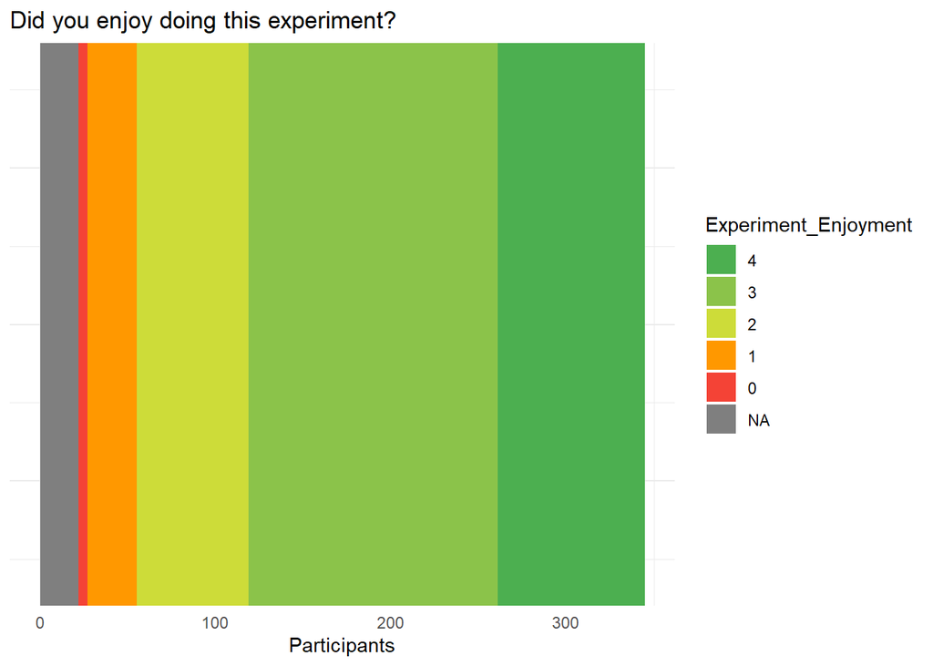

```r
df |>
  summarize(n = n(), .by="Experiment_Enjoyment") |>
  arrange(desc(Experiment_Enjoyment)) |>
  mutate(Experiment_Enjoyment = fct_rev(as.factor(Experiment_Enjoyment))) |>
  ggplot(aes(x=0, y=n)) +
  geom_bar(aes(fill=Experiment_Enjoyment), stat="identity") +
  scale_fill_manual(values=c("#4CAF50", "#8BC34A", "#CDDC39", "#FF9800", "#F44336")) +
  scale_x_continuous(expand=c(0, 0)) +
  coord_flip() +
  theme_minimal() +
  theme(axis.title.y = element_blank(),
        axis.ticks.y = element_blank(),
        axis.text.y = element_blank()) +
  labs(x="Answer", y = "Participants", title = "Did you enjoy doing this experiment?")
```

### Proportions

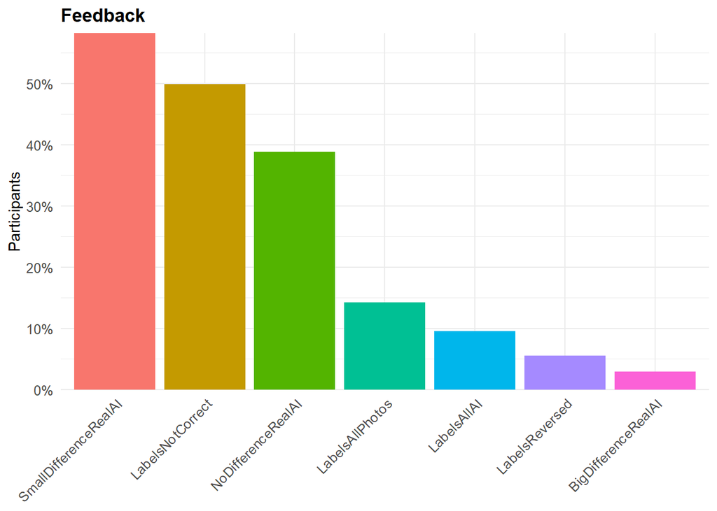

```r
df |>
  select(starts_with("Feedback"), -ends_with(c("Real", "Fake")), -Experiment_Enjoyment) |>
  pivot_longer(everything(), names_to = "Question", values_to = "Answer") |>
  group_by(Question, Answer) |>
  summarise(prop = n()/nrow(df), .groups = 'drop') |>
  complete(Question, Answer, fill = list(prop = 0)) |>
  filter(Answer == "TRUE") |>
  mutate(Question = str_remove(Question, "Feedback_"),
         Question = str_replace(Question, "Feedback_LabelsNotCorrect", "Labels were Incorrect"),
         Question = str_replace(Question, "Feedback_LabelsReversed", "Labels were Reversed"),
         Question = str_replace(Question, "Feedback_NoDifferenceRealAI", "No Difference Real/AI"),
         Question = str_replace(Question, "Feedback_BigDifferenceRealAI", "Big difference Real/AI"),
         Question = str_replace(Question, "Feedback_SmallDifferenceRealAI", "Small difference Real/AI"),
         Question = str_replace(Question, "Feedback_LabelsAllPhotos", "All Faces were photographs"),
         Question = str_replace(Question, "Feedback_LabelsAllAI", "All Faces were AI-generated")) |>
  mutate(Question = fct_reorder(Question, desc(prop))) |>
  ggplot(aes(x = Question, y = prop, fill = Question)) +
  # scale_fill_manual(values=c("#4CAF50", "#8BC34A", "#CDDC39", "#FF9800", "#F44336", "#3242a8", "#8332a8")) +
  geom_bar(stat = "identity") +
  scale_y_continuous(expand = c(0, 0), breaks= scales::pretty_breaks(), labels=scales::percent) +
  labs(x="Feedback", y = "Participants", title = "Feedback") +
  theme_minimal() +
  theme(
    plot.title = element_text(size = rel(1.2), face = "bold", hjust = 0),
    plot.subtitle = element_text(size = rel(1.2), vjust = 7),
    axis.text.y = element_text(size = rel(1.1)),
    axis.text.x = element_text(size = rel(1.1), angle = 45, hjust = 1),
    axis.title.x = element_blank(),
    legend.position = "none"
  )
```

## Exclusions

```r
outliers <- list()
```

### Age

```r
outliers$age <- filter(df, Age >=95 | Age < 18 )$Participant
```

we removed 1 participants whose ages were under 18 or above 95, as these values were unlikely given our undergraduate sample.

```r
df <- filter(df, !Participant %in% outliers$age)
dftask <- filter(dftask, !Participant %in% outliers$age)
```

### Mobile

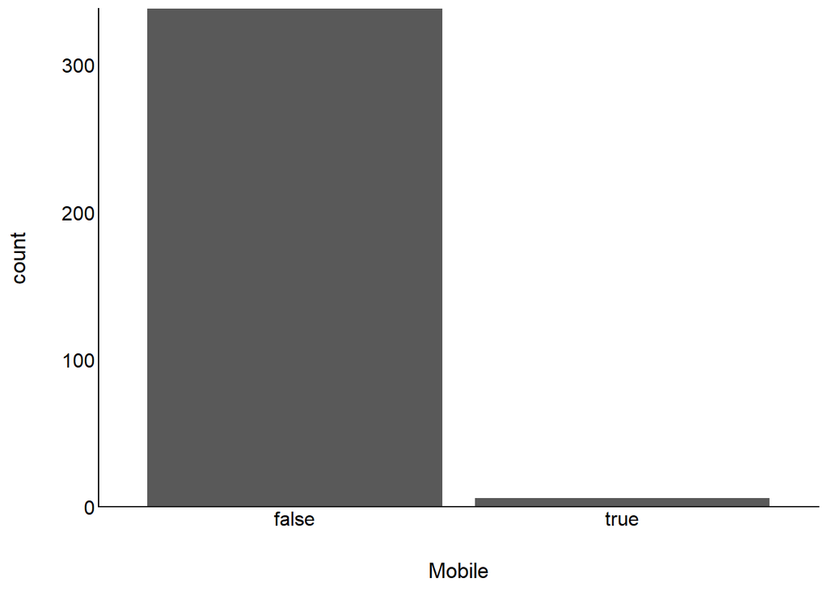

```r
df |>
  ggplot(aes(x=Mobile)) +
  geom_bar() +
  theme_modern() +
  scale_y_continuous(expand=c(0, 0))
```

There were 6 participants that used a mobile device.

### Invalid Responses

```r
outliers$invalid <- dftask |>
  group_by(Participant) |>
  summarize(Mean_Attractiveness = mean(Attractiveness),
            SD_Attractiveness = sd(Attractiveness),
            N_Attractiveness = length(unique(Attractiveness)),
            SD_Symmetry = sd(Symmetry),
            SD_Beauty = sd(Beauty)) |>
  arrange(N_Attractiveness) |>
  filter(SD_Attractiveness == 0 | SD_Symmetry == 0 | SD_Beauty == 0)

# gt::gt(outliers$invalid)

outliers$invalid <- outliers$invalid$Participant
```

0 participants had no variation in their responses.

### Experiment Duration

The experiment’s median duration is 24.45 min (50% HDI [19.36, 26.13]).

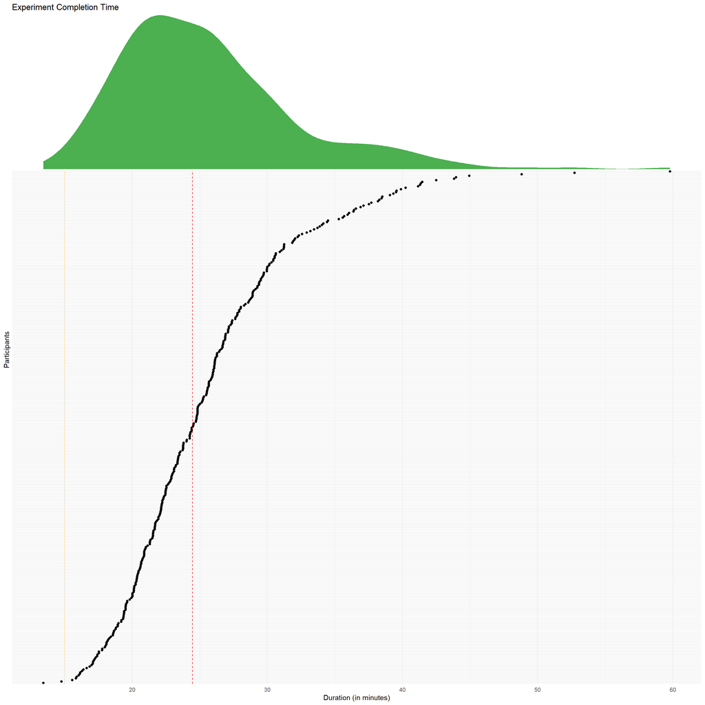

```r
df |>
  mutate(Participant = fct_reorder(Participant, Experiment_Duration),
         Category = ifelse(Experiment_Duration > 60, "extra", "ok"),
         Duration = ifelse(Experiment_Duration > 60, 60, Experiment_Duration),
         Group = ifelse(Participant %in% outliers, "Outlier", "ok")) |>
  ggplot(aes(y = Participant, x = Duration)) +
  geom_point(aes(color = Group, shape = Category)) +
  geom_vline(xintercept = median(df$Experiment_Duration), color = "red", linetype = "dashed") +
  geom_vline(xintercept = 15, color = "orange", linetype = "dotted") +
  scale_shape_manual(values = c("extra" = 3, ok = 19)) +
  scale_color_manual(values = c("Outlier" = "red", ok = "black"), guide="none") +
  guides(color = "none", shape = "none") +
  ggside::geom_xsidedensity(fill = "#4CAF50", color=NA) +
  ggside::scale_xsidey_continuous(expand = c(0, 0)) +
  labs(
    title = "Experiment Completion Time",
    x = "Duration (in minutes)",
    y = "Participants"
  )  +
  theme_minimal() +
  ggside::theme_ggside_void() +
  theme(ggside.panel.scale = .3,
        panel.border = element_blank(),
        axis.text.y = element_blank(),
        axis.ticks.y = element_blank())
```

```r
outliers$expe_duration <- filter(df, Experiment_Duration < 15)$Participant
```

We removed 2 participants for completing the experiment under 15 minutes.

```r
df <- filter(df, !Participant %in% outliers$expe_duration)
dftask <- filter(dftask, !Participant %in% outliers$expe_duration)
```

## Final Sample

### Age

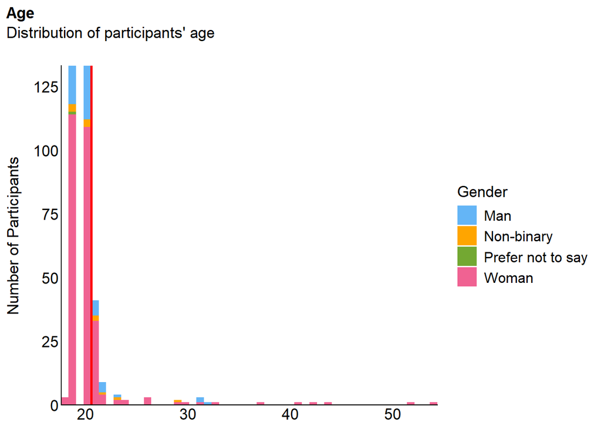

```r
p_age <- estimate_density(df$Age) |>
  normalize(select = y) |>
  mutate(y = y * 86) |>  # To match the binwidth
  ggplot(aes(x = x)) +
  geom_histogram(data=df, aes(x = Age, fill=Gender), bins=50 ) +
  # geom_line(aes(y = y), color = "orange", linewidth=2) +
  geom_vline(xintercept = mean(df$Age), color = "red", linewidth=1) +
  # geom_label(data = data.frame(x = mean(df$Age) * 1.15, y = 0.95 * 75), aes(y = y), color = "red", label = paste0("Mean = ", format_value(mean(df$Age)))) +
  scale_fill_manual(values = c("Man"= "#64B5F6", "Woman"= "#F06292", "Non-binary"="orange", "Prefer not to say" = "#73a832" )) +
  scale_x_continuous(expand = c(0, 0)) +
  scale_y_continuous(expand = c(0, 0)) +
  labs(title = "Age", y = "Number of Participants", color = NULL, subtitle = "Distribution of participants' age") +
  theme_modern(axis.title.space = 10) +
  theme(
    plot.title = element_text(size = rel(1.2), face = "bold", hjust = 0),
    plot.subtitle = element_text(size = rel(1.2), vjust = 7),
    axis.text.y = element_text(size = rel(1.1)),
    axis.text.x = element_text(size = rel(1.1)),
    axis.title.x = element_blank()
  )
p_age
```

### Sexual Profile

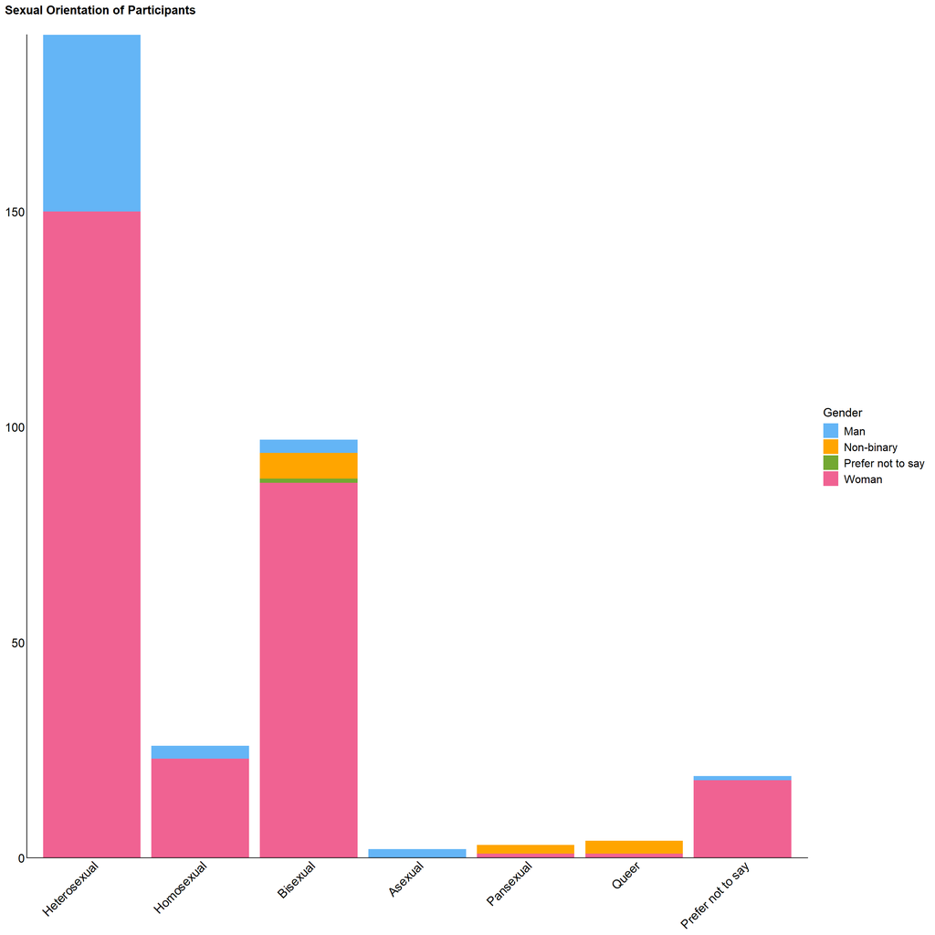

```r
df |>
  mutate(SexualOrientation = fct_relevel(SexualOrientation, "Heterosexual", "Homosexual", "Bisexual", "Asexual", "Pansexual", "Queer", "Prefer not to say")) |>
  ggplot(aes(x = SexualOrientation)) +
  geom_bar(aes(fill=Gender)) +
  scale_y_continuous(expand = c(0, 0), breaks= scales::pretty_breaks()) +
  scale_fill_manual(values = c("Man"= "#64B5F6", "Woman"= "#F06292", "Non-binary"="orange", "Prefer not to say" = "#73a832")) +
  labs(title = "Sexual Orientation of Participants") +
  theme_modern(axis.title.space = 15) +
  theme(
    plot.title = element_text(size = rel(1.2), face = "bold", hjust = 0),
    plot.subtitle = element_text(size = rel(1.2), vjust = 7),
    axis.text.y = element_text(size = rel(1.1)),
    axis.text.x = element_text(size = rel(1.1), angle = 45, hjust = 1),
    axis.title.x = element_blank(),
    axis.title.y = element_blank()
  )
```

## Undergraduates dataset

### Proportions of faces judged as real

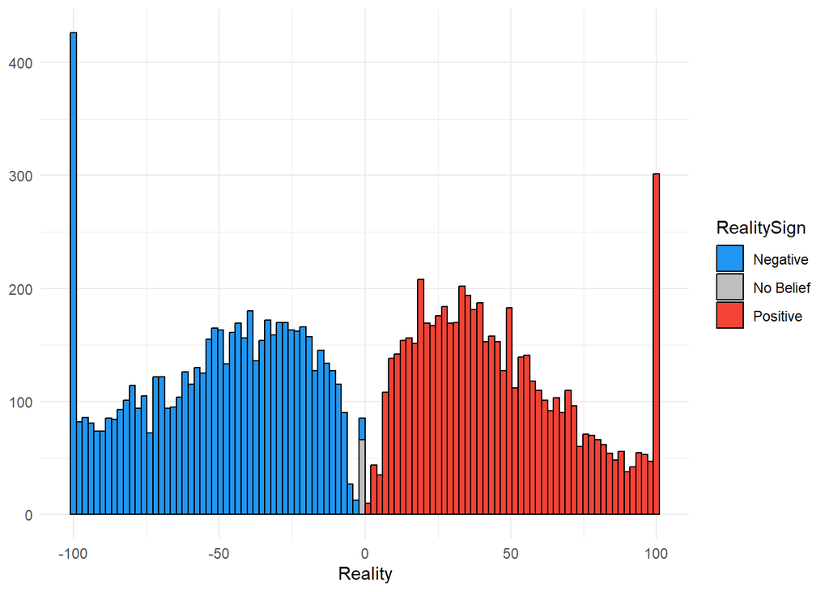

```r
reality <- dftask |>
  mutate(JudgedReal = Reality > 0) |>
  group_by(Participant) |>
  summarise(ProportionReal = mean(JudgedReal, na.rm = TRUE))

dftask |>
    mutate(
    RealitySign = case_when(
      Reality < -0.5 ~ "Negative",
      Reality > 0.5 ~ "Positive",
      Reality == 0 ~ "No Belief")) |>
  ggplot(aes(x = Reality, fill = RealitySign)) +
  geom_histogram(bins = 100, color = "black") +
  scale_fill_manual(values = c("Negative" = "#2196F3", "Positive" = "#F44336", "No Belief" = "grey")) +
  theme_minimal() +
  theme(axis.title.y = element_blank())
```

### Ratings

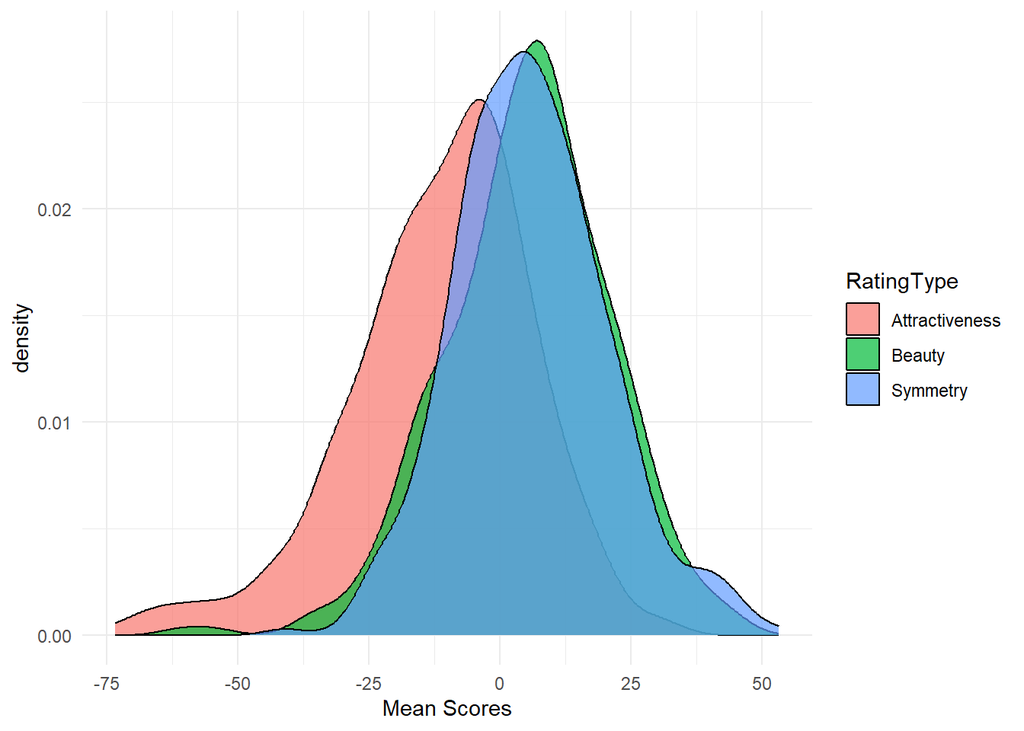

```r
ratings <- dftask |>
  group_by(Participant) |>
    summarise(Mean_Attractiveness = mean(Attractiveness, na.rm = TRUE),
            Mean_Beauty = mean(Beauty, na.rm = TRUE),
            Mean_Symmetry = mean(Symmetry, na.rm = TRUE))


ratings |>
  rename(Attractiveness = "Mean_Attractiveness",
         Beauty = "Mean_Beauty",
         Symmetry = "Mean_Symmetry") |>
  pivot_longer(
    cols = c(Attractiveness, Beauty, Symmetry),
    names_to = "RatingType",
    values_to = "Mean"
  )|>
  ggplot(aes(x = Mean, fill = RatingType)) +
  geom_density(alpha = 0.7) +
  theme_minimal() +
  labs(x = "Mean Scores")
```

```r
data_final <- df |>
  select(Participant, Age, Gender, SexualOrientation, Ethnicity, MIST_totalcorrect, BAIT_total, BRS_Total, Questionnaires_AttentionCheck) |>
  full_join(ratings,by = join_by(Participant))  |>
 arrange(as.numeric(gsub("\\D", "", Participant))) |>
  mutate(
    Participant = str_c("S", str_pad(row_number(), 3, pad = "0")),
    Gender = sample(Gender),
    SexualOrientation = sample(SexualOrientation),
    Ethnicity = sample(Ethnicity),
    Age = sample(Age))


head(data_final) |> gt::gt()
```

| Participant | Age | Gender | SexualOrientation | Ethnicity | MIST_totalcorrect | BAIT_total | BRS_Total | Questionnaires_AttentionCheck | Mean_Attractiveness | Mean_Beauty | Mean_Symmetry |
| --- | --- | --- | --- | --- | --- | --- | --- | --- | --- | --- | --- |
| S001 | 19 | Woman | Heterosexual | Mixed | 6 | 3.291667 | 3.05 | 1 | -1.666667 | 32.666667 | 14.361111 |
| S002 | 19 | Woman | Bisexual | White | 4 | 3.166667 | 3.15 | 1 | -30.194444 | 10.333333 | 14.305556 |
| S003 | 20 | Woman | Prefer not to say | Black | 5 | 2.750000 | 3.10 | 1 | -18.055556 | -5.472222 | -5.416667 |
| S004 | 20 | Woman | Bisexual | White | 8 | 2.000000 | 3.20 | 1 | -26.888889 | -6.111111 | 10.416667 |
| S005 | 19 | Woman | Bisexual | Mixed | 6 | 2.250000 | 3.85 | 1 | -15.472222 | 5.138889 | 10.416667 |
| S006 | 20 | Woman | Homosexual | White | 4 | 1.458333 | 2.35 | 1 | -18.583333 | 16.444444 | 11.694444 |

## Save

```r
write.csv(df, "../data/data_participants.csv", row.names = FALSE)
write.csv(dftask, "../data/data_task.csv", row.names = FALSE)
write.csv(data_final, "../data/data_undergraduates.csv", row.names = FALSE)
```